# Project: Investigate a Dataset(imDb movie dataset)

- Introduction
- Data Gathering and Assessing
- Data Cleaning
- Exploratory Data Analysis
- Conclusions

## Introduction

> This data set contains information about 10,000 movies collected from The Movie Database (TMDb), including user ratings and revenue.
> - Certain columns, like ‘cast’ and ‘genres’, contain multiple values separated by pipe (|) characters.
> - There are some odd characters in the ‘cast’ column.
> - The final two columns ending with “_adj” show the budget and revenue of the associated movie in terms of 2010 dollars, accounting for inflation over time. -The source of this data is www.kaggle.com.

The questions I will be Going through are:

2.Which year has the most number of movie release?

3.What kinds of properties are associated with movies that have high revenues?

4.Investigating trends in revenue_adj above the mean value and below the mean value

5.What are the top movies by vote average (Average rating) and popularity?

6.What is the average runtime of all movies and further analysis:

7.Calculating top 10 by count.....

a)Which directors made maximum no of movies?

```python
# Use this cell to set up import statements for all of the packages that you
#   plan to use.

# Remember to include a 'magic word' so that your visualizations are plotted
#   inline with the notebook. See this page for more:
#   http://ipython.readthedocs.io/en/stable/interactive/magics.html
import numpy as np
import pandas as pd
import matplotlib.pyplot as plt
import seaborn as sb
%matplotlib inline
```

## Data Gathering and Assessing

> In this section of the report, I will the load in the data, check for cleanliness, and report those points to be used for cleaning section. I will explain each of my steps while performing them.
1. Loading the CSV file

```python
data=pd.read_csv('tmdb-movies.csv')
```

1. Using the head command displaying the first five values (by default)

```python
data.head()
```

|  | id | imdb_id | popularity | budget | revenue | original_title | cast | homepage | director | tagline | ... | overview | runtime | genres | production_companies | release_date | vote_count | vote_average | release_year | budget_adj | revenue_adj |
| --- | --- | --- | --- | --- | --- | --- | --- | --- | --- | --- | --- | --- | --- | --- | --- | --- | --- | --- | --- | --- | --- |
| 0 | 135397 | tt0369610 | 32.985763 | 150000000 | 1513528810 | Jurassic World | Chris Pratt\|Bryce Dallas Howard\|Irrfan Khan\|Vi... | http://www.jurassicworld.com/ | Colin Trevorrow | The park is open. | ... | Twenty-two years after the events of Jurassic ... | 124 | Action\|Adventure\|Science Fiction\|Thriller | Universal Studios\|Amblin Entertainment\|Legenda... | 6/9/15 | 5562 | 6.5 | 2015 | 1.379999e+08 | 1.392446e+09 |
| 1 | 76341 | tt1392190 | 28.419936 | 150000000 | 378436354 | Mad Max: Fury Road | Tom Hardy\|Charlize Theron\|Hugh Keays-Byrne\|Nic... | http://www.madmaxmovie.com/ | George Miller | What a Lovely Day. | ... | An apocalyptic story set in the furthest reach... | 120 | Action\|Adventure\|Science Fiction\|Thriller | Village Roadshow Pictures\|Kennedy Miller Produ... | 5/13/15 | 6185 | 7.1 | 2015 | 1.379999e+08 | 3.481613e+08 |
| 2 | 262500 | tt2908446 | 13.112507 | 110000000 | 295238201 | Insurgent | Shailene Woodley\|Theo James\|Kate Winslet\|Ansel... | http://www.thedivergentseries.movie/#insurgent | Robert Schwentke | One Choice Can Destroy You | ... | Beatrice Prior must confront her inner demons ... | 119 | Adventure\|Science Fiction\|Thriller | Summit Entertainment\|Mandeville Films\|Red Wago... | 3/18/15 | 2480 | 6.3 | 2015 | 1.012000e+08 | 2.716190e+08 |
| 3 | 140607 | tt2488496 | 11.173104 | 200000000 | 2068178225 | Star Wars: The Force Awakens | Harrison Ford\|Mark Hamill\|Carrie Fisher\|Adam D... | http://www.starwars.com/films/star-wars-episod... | J.J. Abrams | Every generation has a story. | ... | Thirty years after defeating the Galactic Empi... | 136 | Action\|Adventure\|Science Fiction\|Fantasy | Lucasfilm\|Truenorth Productions\|Bad Robot | 12/15/15 | 5292 | 7.5 | 2015 | 1.839999e+08 | 1.902723e+09 |
| 4 | 168259 | tt2820852 | 9.335014 | 190000000 | 1506249360 | Furious 7 | Vin Diesel\|Paul Walker\|Jason Statham\|Michelle ... | http://www.furious7.com/ | James Wan | Vengeance Hits Home | ... | Deckard Shaw seeks revenge against Dominic Tor... | 137 | Action\|Crime\|Thriller | Universal Pictures\|Original Film\|Media Rights ... | 4/1/15 | 2947 | 7.3 | 2015 | 1.747999e+08 | 1.385749e+09 |

5 rows × 21 columns

1. Checking the size of the table i.e., the number of rows and columns in the dataset

```python
data.shape
```

```
(10866, 21)
```

Therefore the table has a total of 10866 number of rows and 21 columns.

1. Describe function shows the means, minimum values, count and many other properties of dataset

```python
data.describe()
```

|  | id | popularity | budget | revenue | runtime | vote_count | vote_average | release_year | budget_adj | revenue_adj |
| --- | --- | --- | --- | --- | --- | --- | --- | --- | --- | --- |
| count | 10866.000000 | 10866.000000 | 1.086600e+04 | 1.086600e+04 | 10866.000000 | 10866.000000 | 10866.000000 | 10866.000000 | 1.086600e+04 | 1.086600e+04 |
| mean | 66064.177434 | 0.646441 | 1.462570e+07 | 3.982332e+07 | 102.070863 | 217.389748 | 5.974922 | 2001.322658 | 1.755104e+07 | 5.136436e+07 |
| std | 92130.136561 | 1.000185 | 3.091321e+07 | 1.170035e+08 | 31.381405 | 575.619058 | 0.935142 | 12.812941 | 3.430616e+07 | 1.446325e+08 |
| min | 5.000000 | 0.000065 | 0.000000e+00 | 0.000000e+00 | 0.000000 | 10.000000 | 1.500000 | 1960.000000 | 0.000000e+00 | 0.000000e+00 |
| 25% | 10596.250000 | 0.207583 | 0.000000e+00 | 0.000000e+00 | 90.000000 | 17.000000 | 5.400000 | 1995.000000 | 0.000000e+00 | 0.000000e+00 |
| 50% | 20669.000000 | 0.383856 | 0.000000e+00 | 0.000000e+00 | 99.000000 | 38.000000 | 6.000000 | 2006.000000 | 0.000000e+00 | 0.000000e+00 |
| 75% | 75610.000000 | 0.713817 | 1.500000e+07 | 2.400000e+07 | 111.000000 | 145.750000 | 6.600000 | 2011.000000 | 2.085325e+07 | 3.369710e+07 |
| max | 417859.000000 | 32.985763 | 4.250000e+08 | 2.781506e+09 | 900.000000 | 9767.000000 | 9.200000 | 2015.000000 | 4.250000e+08 | 2.827124e+09 |

1. Info function tells about the number of non null values and data types in the dataset.

```python
data.info();
```

```
<class 'pandas.core.frame.DataFrame'>
RangeIndex: 10866 entries, 0 to 10865
Data columns (total 21 columns):
 #   Column                Non-Null Count  Dtype
---  ------                --------------  -----
 0   id                    10866 non-null  int64
 1   imdb_id               10856 non-null  object
 2   popularity            10866 non-null  float64
 3   budget                10866 non-null  int64
 4   revenue               10866 non-null  int64
 5   original_title        10866 non-null  object
 6   cast                  10790 non-null  object
 7   homepage              2936 non-null   object
 8   director              10822 non-null  object
 9   tagline               8042 non-null   object
 10  keywords              9373 non-null   object
 11  overview              10862 non-null  object
 12  runtime               10866 non-null  int64
 13  genres                10843 non-null  object
 14  production_companies  9836 non-null   object
 15  release_date          10866 non-null  object
 16  vote_count            10866 non-null  int64
 17  vote_average          10866 non-null  float64
 18  release_year          10866 non-null  int64
 19  budget_adj            10866 non-null  float64
 20  revenue_adj           10866 non-null  float64
dtypes: float64(4), int64(6), object(11)
memory usage: 1.7+ MB
```

Check for inncorrect data types We can see that release_date has object data type which here means it has string datatype so we will have to convert it into appropriate data type i.e., datetime also imdb_id should be of int type

1. nunique function tells us about the no. of unique values in each column.

```python
data.nunique()
```

```
id                      10865
imdb_id                 10855
popularity              10814
budget                    557
revenue                  4702
original_title          10571
cast                    10719
homepage                 2896
director                 5067
tagline                  7997
keywords                 8804
overview                10847
runtime                   247
genres                   2039
production_companies     7445
release_date             5909
vote_count               1289
vote_average               72
release_year               56
budget_adj               2614
revenue_adj              4840
dtype: int64
```

1. Check for Null values with the help of isnull() function and sum() function to count the number of nulls

```python
data.isnull().sum()
```

```
id                         0
imdb_id                   10
popularity                 0
budget                     0
revenue                    0
original_title             0
cast                      76
homepage                7930
director                  44
tagline                 2824
keywords                1493
overview                   4
runtime                    0
genres                    23
production_companies    1030
release_date               0
vote_count                 0
vote_average               0
release_year               0
budget_adj                 0
revenue_adj                0
dtype: int64
```

As we can see from the above result attributes like imbd_id,cast,homepage,director,tagline,keywords,overview etc.,have null values in them .

1. Check for Duplicate values by using the duplicated() function

```python
data.duplicated().sum()
```

```
1
```

### To be done under cleaned section

- change data type of release_date to date
- imdb_id should be of int type by removing tt characters from the start of every cell in column
- Delete duplicate data
- drop nulls
- remove the unnecessary columns which have no relation with our investigation process

## Data Cleaning

After discussing the structure of the data and any problems that need to be cleaned, perform those cleaning steps in the second part of this section.

- Here we are changing the data type of relase_date to datetime:

```python
data.release_date=pd.to_datetime(data.release_date)
```

```python
data.imdb_id=data.imdb_id.str[2:].astype(float)
data.info();
```

```
<class 'pandas.core.frame.DataFrame'>
RangeIndex: 10866 entries, 0 to 10865
Data columns (total 21 columns):
 #   Column                Non-Null Count  Dtype
---  ------                --------------  -----
 0   id                    10866 non-null  int64
 1   imdb_id               10856 non-null  float64
 2   popularity            10866 non-null  float64
 3   budget                10866 non-null  int64
 4   revenue               10866 non-null  int64
 5   original_title        10866 non-null  object
 6   cast                  10790 non-null  object
 7   homepage              2936 non-null   object
 8   director              10822 non-null  object
 9   tagline               8042 non-null   object
 10  keywords              9373 non-null   object
 11  overview              10862 non-null  object
 12  runtime               10866 non-null  int64
 13  genres                10843 non-null  object
 14  production_companies  9836 non-null   object
 15  release_date          10866 non-null  datetime64[ns]
 16  vote_count            10866 non-null  int64
 17  vote_average          10866 non-null  float64
 18  release_year          10866 non-null  int64
 19  budget_adj            10866 non-null  float64
 20  revenue_adj           10866 non-null  float64
dtypes: datetime64[ns](1), float64(5), int64(6), object(9)
memory usage: 1.7+ MB
```

- Now we will remove the duplicate row with the help of drop_duplicates function

```python
data.drop_duplicates(inplace=True)
data.duplicated().sum()
```

```
0
```

- Now we will remove the null values using dropna function.

```python
data.dropna(inplace=True)
data.isnull().sum()
```

```
id                      0
imdb_id                 0
popularity              0
budget                  0
revenue                 0
original_title          0
cast                    0
homepage                0
director                0
tagline                 0
keywords                0
overview                0
runtime                 0
genres                  0
production_companies    0
release_date            0
vote_count              0
vote_average            0
release_year            0
budget_adj              0
revenue_adj             0
dtype: int64
```

- Now we will remove the unnecessary columns which have no relation with our investigation process

```python
data = data.drop(['imdb_id','budget','revenue','overview','homepage','tagline'],axis = 1)
```

```python
print(data.shape)
data.head(2)
```

[output not shown]

|  | id | popularity | original_title | cast | director | keywords | runtime | genres | production_companies | release_date | vote_count | vote_average | release_year | budget_adj | revenue_adj |
| --- | --- | --- | --- | --- | --- | --- | --- | --- | --- | --- | --- | --- | --- | --- | --- |
| 0 | 135397 | 32.985763 | Jurassic World | Chris Pratt\|Bryce Dallas Howard\|Irrfan Khan\|Vi... | Colin Trevorrow | monster\|dna\|tyrannosaurus rex\|velociraptor\|island | 124 | Action\|Adventure\|Science Fiction\|Thriller | Universal Studios\|Amblin Entertainment\|Legenda... | 2015-06-09 | 5562 | 6.5 | 2015 | 1.379999e+08 | 1.392446e+09 |
| 1 | 76341 | 28.419936 | Mad Max: Fury Road | Tom Hardy\|Charlize Theron\|Hugh Keays-Byrne\|Nic... | George Miller | future\|chase\|post-apocalyptic\|dystopia\|australia | 120 | Action\|Adventure\|Science Fiction\|Thriller | Village Roadshow Pictures\|Kennedy Miller Produ... | 2015-05-13 | 6185 | 7.1 | 2015 | 1.379999e+08 | 3.481613e+08 |

## Exploratory Data Analysis

> Now that we have trimmed and cleaned our data, we are ready to move on to exploration. Compute statistics and create visualizations with the goal of addressing the research questions that we posed in the Introduction section.

#### Assigning a new column which will hold the profit values of each movie.

```python
#To calculate profit of each movie, we need to substract the budget from the revenue of each movie
data.insert(2, 'profit', data['revenue_adj'] - data['budget_adj'])

#showing the dataset
data.head()
```

|  | id | popularity | profit | original_title | cast | director | keywords | runtime | genres | production_companies | release_date | vote_count | vote_average | release_year | budget_adj | revenue_adj |
| --- | --- | --- | --- | --- | --- | --- | --- | --- | --- | --- | --- | --- | --- | --- | --- | --- |
| 0 | 135397 | 32.985763 | 1.254446e+09 | Jurassic World | Chris Pratt\|Bryce Dallas Howard\|Irrfan Khan\|Vi... | Colin Trevorrow | monster\|dna\|tyrannosaurus rex\|velociraptor\|island | 124 | Action\|Adventure\|Science Fiction\|Thriller | Universal Studios\|Amblin Entertainment\|Legenda... | 2015-06-09 | 5562 | 6.5 | 2015 | 1.379999e+08 | 1.392446e+09 |
| 1 | 76341 | 28.419936 | 2.101614e+08 | Mad Max: Fury Road | Tom Hardy\|Charlize Theron\|Hugh Keays-Byrne\|Nic... | George Miller | future\|chase\|post-apocalyptic\|dystopia\|australia | 120 | Action\|Adventure\|Science Fiction\|Thriller | Village Roadshow Pictures\|Kennedy Miller Produ... | 2015-05-13 | 6185 | 7.1 | 2015 | 1.379999e+08 | 3.481613e+08 |
| 2 | 262500 | 13.112507 | 1.704191e+08 | Insurgent | Shailene Woodley\|Theo James\|Kate Winslet\|Ansel... | Robert Schwentke | based on novel\|revolution\|dystopia\|sequel\|dyst... | 119 | Adventure\|Science Fiction\|Thriller | Summit Entertainment\|Mandeville Films\|Red Wago... | 2015-03-18 | 2480 | 6.3 | 2015 | 1.012000e+08 | 2.716190e+08 |
| 3 | 140607 | 11.173104 | 1.718723e+09 | Star Wars: The Force Awakens | Harrison Ford\|Mark Hamill\|Carrie Fisher\|Adam D... | J.J. Abrams | android\|spaceship\|jedi\|space opera\|3d | 136 | Action\|Adventure\|Science Fiction\|Fantasy | Lucasfilm\|Truenorth Productions\|Bad Robot | 2015-12-15 | 5292 | 7.5 | 2015 | 1.839999e+08 | 1.902723e+09 |
| 4 | 168259 | 9.335014 | 1.210949e+09 | Furious 7 | Vin Diesel\|Paul Walker\|Jason Statham\|Michelle ... | James Wan | car race\|speed\|revenge\|suspense\|car | 137 | Action\|Crime\|Thriller | Universal Pictures\|Original Film\|Media Rights ... | 2015-04-01 | 2947 | 7.3 | 2015 | 1.747999e+08 | 1.385749e+09 |

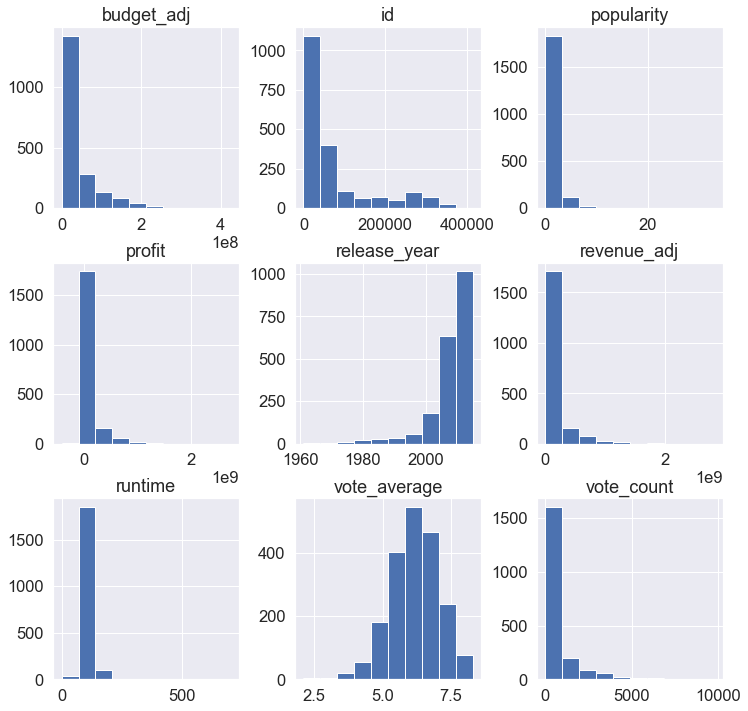

```python
# Use this, and more code cells, to explore your data.
data.genres.value_counts()
data.hist(figsize=(12,12));
```

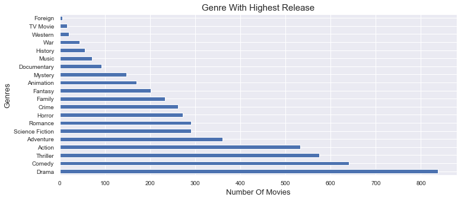

```python
# function will will split the string and return the count of each genre.
def count_genre_type(x):
    #concatenate all the rows of the genrs.
    data_plot = data[x].str.cat(sep = '|')
    df = pd.Series(data_plot.split('|'))
    #conts each of the genre and return.
    info = df.value_counts(ascending=False)
    return info

#call the function for counting the movies of each genre.
total_genre_movies = count_genre_type('genres')
# plot using plot function for 'genre vs number of movies'.
total_genre_movies.plot(kind= 'barh',figsize = (12,5),fontsize=10)

#setup the title and the labels of the plot.
plt.title("Genre With Highest Release",fontsize=15)
plt.xlabel('Number Of Movies',fontsize=13)
plt.ylabel("Genres",fontsize= 13)
```

Here we have splitted the genres column by '|' and created new rows for each separated genre.

Then we plotted these genres in a bar graph.From the bar graph we can clearly conclude about the most common genre in movies i.e., Drama and the second one is comedy.

The least used genre by movies is Foreign.

```python
data.head(2)
```

|  | id | popularity | profit | original_title | cast | director | keywords | runtime | genres | production_companies | release_date | vote_count | vote_average | release_year | budget_adj | revenue_adj |
| --- | --- | --- | --- | --- | --- | --- | --- | --- | --- | --- | --- | --- | --- | --- | --- | --- |
| 0 | 135397 | 32.985763 | 1.254446e+09 | Jurassic World | Chris Pratt\|Bryce Dallas Howard\|Irrfan Khan\|Vi... | Colin Trevorrow | monster\|dna\|tyrannosaurus rex\|velociraptor\|island | 124 | Action\|Adventure\|Science Fiction\|Thriller | Universal Studios\|Amblin Entertainment\|Legenda... | 2015-06-09 | 5562 | 6.5 | 2015 | 1.379999e+08 | 1.392446e+09 |
| 1 | 76341 | 28.419936 | 2.101614e+08 | Mad Max: Fury Road | Tom Hardy\|Charlize Theron\|Hugh Keays-Byrne\|Nic... | George Miller | future\|chase\|post-apocalyptic\|dystopia\|australia | 120 | Action\|Adventure\|Science Fiction\|Thriller | Village Roadshow Pictures\|Kennedy Miller Produ... | 2015-05-13 | 6185 | 7.1 | 2015 | 1.379999e+08 | 3.481613e+08 |

### 2. Which year has the most number of movie release?

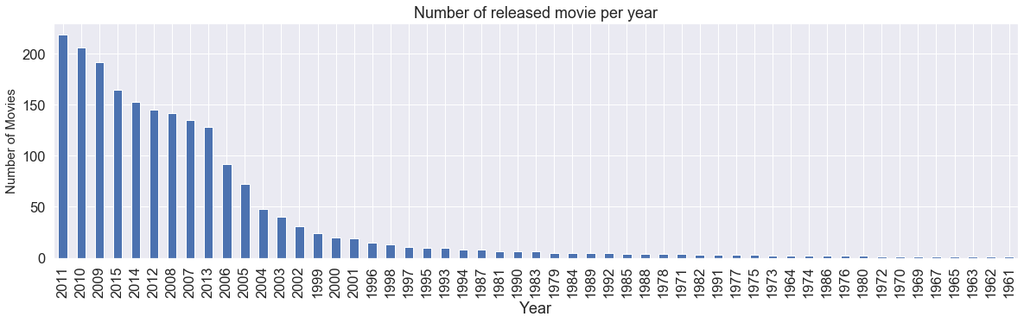

```python
fig = plt.figure(figsize=(20,5))
mon=data['release_year'].value_counts().plot.bar()
plt.title('Number of released movie per year',fontsize=18)
plt.xlabel('Year',fontsize=18)
plt.ylabel('Number of Movies',fontsize=15)

plt.show()
```

The Bar plot clearly shows the trend in the number of movies released that has been increasing over the years.

### 3. What kinds of properties are associated with movies that have high revenues?

```python
points = pd.DataFrame(data['revenue_adj'].sort_values(ascending=False))
data_set = ['id','popularity','budget_adj','original_title','cast','director','genres','vote_average','release_year']
for i in data_set:
    points[i] = data[i]
points.head(3)
```

|  | revenue_adj | id | popularity | budget_adj | original_title | cast | director | genres | vote_average | release_year |
| --- | --- | --- | --- | --- | --- | --- | --- | --- | --- | --- |
| 1386 | 2.827124e+09 | 19995 | 9.432768 | 2.408869e+08 | Avatar | Sam Worthington\|Zoe Saldana\|Sigourney Weaver\|S... | James Cameron | Action\|Adventure\|Fantasy\|Science Fiction | 7.1 | 2009 |
| 1329 | 2.789712e+09 | 11 | 12.037933 | 3.957559e+07 | Star Wars | Mark Hamill\|Harrison Ford\|Carrie Fisher\|Peter ... | George Lucas | Adventure\|Action\|Science Fiction | 7.9 | 1977 |
| 5231 | 2.506406e+09 | 597 | 4.355219 | 2.716921e+08 | Titanic | Kate Winslet\|Leonardo DiCaprio\|Frances Fisher\|... | James Cameron | Drama\|Romance\|Thriller | 7.3 | 1997 |

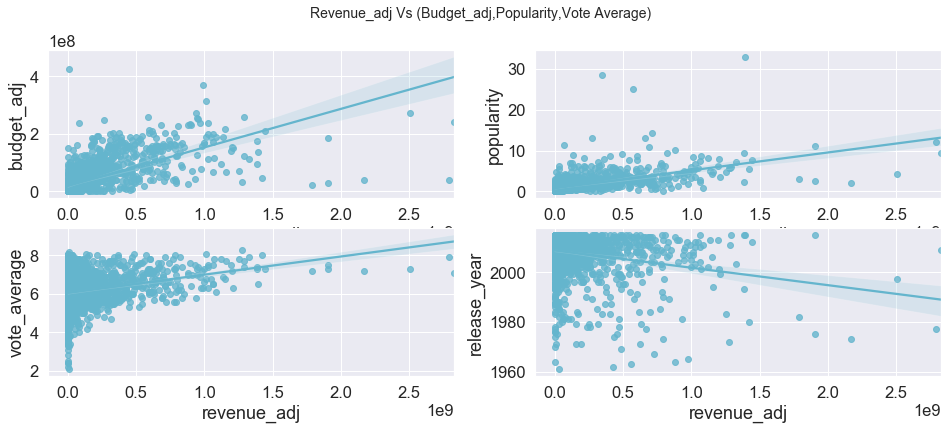

```python
fig, axes = plt.subplots(2,2,figsize = (16,6))
fig.suptitle("Revenue_adj Vs (Budget_adj,Popularity,Vote Average)",fontsize=14)
#info.plot(x = ['revenue_adj'],y = ['budget_adj'],kind = "scatter",ax = axes[0][0])
sb.regplot(x=data['revenue_adj'], y=data['budget_adj'],color='c',ax=axes[0][0])
sb.regplot(x=data['revenue_adj'], y=data['popularity'],color='c',ax=axes[0][1])
sb.regplot(x=data['revenue_adj'], y=data['vote_average'],color='c',ax=axes[1][0])
sb.regplot(x=data['revenue_adj'], y=data['release_year'],color='c',ax=axes[1][1])
```

From the Above regression plots we can define the correlations between the plots we have made :

revenue_adj vs budget_adj: Positive Correlation

revenue_adj Vs popularity: Positive Correlation

revenue_adj Vs vote_average: Positive Correlation

revenue_adj vs release_year: Negative Correlation

### 4. Investigating trends in revenue_adj above the mean value and below the mean value.

```python
# Calculation mean of revenue_adj
x=data.revenue_adj.mean()
x
```

```
130239074.05593592
```

Now we will divide the datase into two parts one below the mean revenue_adj and other above

```python
d1=data.query('revenue_adj >130239074.05593592 ')
d2=data.query('revenue_adj <=130239074.05593592')
```

```python
d1.revenue_adj
```

```
0        1.392446e+09
1        3.481613e+08
2        2.716190e+08
3        1.902723e+09
4        1.385749e+09
             ...
10689    9.771535e+08
10724    4.872780e+08
10759    2.339890e+08
10760    4.713208e+08
10819    2.607307e+08
Name: revenue_adj, Length: 516, dtype: float64
```

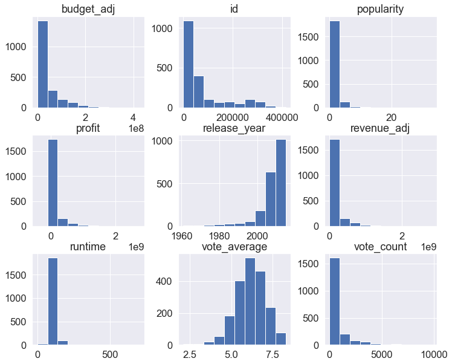

```python
data.hist(figsize=(12,10));
```

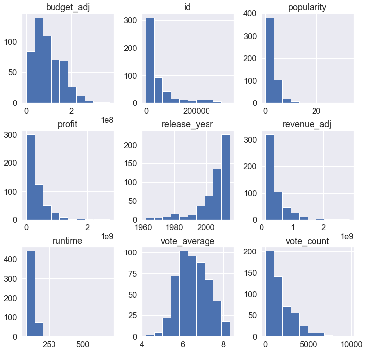

```python
d1.hist(figsize=(12,12));
```

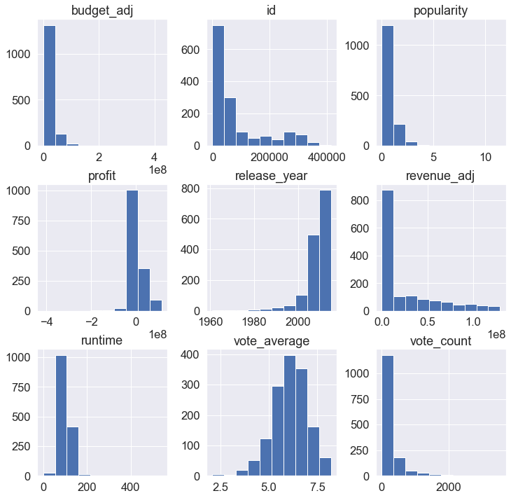

```python
d2.hist(figsize=(12,12));
```

**From Above analysis we can compare the skewness of the properties for above and below mean values.**

- budget_adj:

Above Mean-(Right Skewed)  
Below Mean-(Right Skewed)

- id:

Above Mean- (Right Skewed)  
Below Mean-(Right Skewed)

- popularity:

Above Mean-(Right Skewed)  
Below Mean-(Right Skewed)

- profit:

Above Mean- (Left Skewed)  
Below Mean-(Left Skewed)

- revenue_adj:

Above Mean- (Right Skewed)  
Below Mean-(Right Skewed)

- runtime:

Above Mean- (Right Skewed)  
Below Mean-(Right Skewed)

- vote_average:

Above Mean- (Left Skewed)  
Below Mean-(Left Skewed)

- vote_count:

Above Mean- (Right Skewed)  
Below Mean-(Right Skewed)

```python
d1.describe()
```

|  | id | popularity | profit | runtime | vote_count | vote_average | release_year | budget_adj | revenue_adj |
| --- | --- | --- | --- | --- | --- | --- | --- | --- | --- |
| count | 516.000000 | 516.000000 | 5.160000e+02 | 516.000000 | 516.000000 | 516.000000 | 516.000000 | 5.160000e+02 | 5.160000e+02 |
| mean | 44436.815891 | 2.904831 | 3.374733e+08 | 118.569767 | 1794.511628 | 6.517442 | 2005.515504 | 9.462931e+07 | 4.321026e+08 |
| std | 65789.986273 | 2.907060 | 3.369968e+08 | 33.503064 | 1563.075813 | 0.730265 | 9.988622 | 6.055187e+07 | 3.570740e+08 |
| min | 11.000000 | 0.044675 | -2.103337e+06 | 77.000000 | 13.000000 | 4.200000 | 1962.000000 | 0.000000e+00 | 1.308557e+08 |
| 25% | 1261.250000 | 1.354994 | 1.307729e+08 | 102.000000 | 652.250000 | 6.000000 | 2003.000000 | 4.664570e+07 | 1.963707e+08 |
| 50% | 13138.000000 | 2.123555 | 2.136604e+08 | 115.000000 | 1277.500000 | 6.500000 | 2009.000000 | 8.238966e+07 | 3.122305e+08 |
| 75% | 57908.250000 | 3.444774 | 4.504989e+08 | 130.000000 | 2597.250000 | 7.025000 | 2012.000000 | 1.381333e+08 | 5.499185e+08 |
| max | 331214.000000 | 32.985763 | 2.750137e+09 | 705.000000 | 9767.000000 | 8.300000 | 2015.000000 | 3.683713e+08 | 2.827124e+09 |

```python
d2.describe()
```

|  | id | popularity | profit | runtime | vote_count | vote_average | release_year | budget_adj | revenue_adj |
| --- | --- | --- | --- | --- | --- | --- | --- | --- | --- |
| count | 1476.000000 | 1476.000000 | 1.476000e+03 | 1476.000000 | 1476.000000 | 1476.000000 | 1476.000000 | 1.476000e+03 | 1.476000e+03 |
| mean | 81166.456640 | 0.761585 | 8.836492e+06 | 101.659892 | 241.271680 | 6.060163 | 2008.594173 | 1.587304e+07 | 2.470953e+07 |
| std | 98247.586279 | 0.772559 | 3.006005e+07 | 26.222506 | 363.675549 | 0.899754 | 6.295649 | 2.576982e+07 | 3.498252e+07 |
| min | 17.000000 | 0.000620 | -4.139124e+08 | 0.000000 | 10.000000 | 2.100000 | 1961.000000 | 0.000000e+00 | 0.000000e+00 |
| 25% | 12157.750000 | 0.310469 | -9.693980e+05 | 90.000000 | 34.000000 | 5.500000 | 2007.000000 | 0.000000e+00 | 0.000000e+00 |
| 50% | 40032.000000 | 0.542072 | 0.000000e+00 | 99.000000 | 102.000000 | 6.100000 | 2010.000000 | 4.748721e+06 | 3.537469e+06 |
| 75% | 102126.000000 | 0.977326 | 1.688505e+07 | 110.000000 | 298.250000 | 6.700000 | 2012.000000 | 2.326555e+07 | 4.039133e+07 |
| max | 414419.000000 | 11.422751 | 1.148086e+08 | 540.000000 | 3542.000000 | 8.200000 | 2015.000000 | 4.250000e+08 | 1.295421e+08 |

### 5. What are the top movies by vote average (Average rating) and popularity?

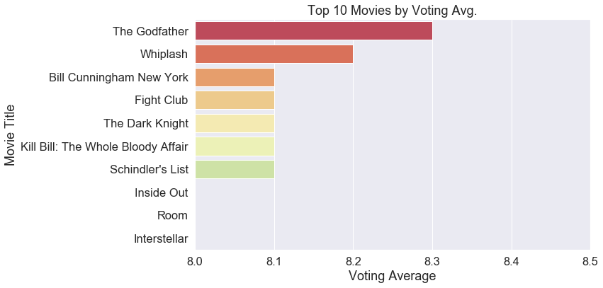

```python
#Get a list of the top 10 movies by voting average
top10 = data.nlargest(10,'vote_average')

#Plot the top 10 movies by voting average
sb.set(style="darkgrid");
sb.set(font_scale=1.5);
f, ax = plt.subplots(figsize=(10, 6));
ax = sb.barplot(x='vote_average', y='original_title', data=top10, palette="Spectral");

ax.set(xlim=(8.0,8.5), ylabel="Movie Title", xlabel="Voting Average");
plt.title('Top 10 Movies by Voting Avg.');
```

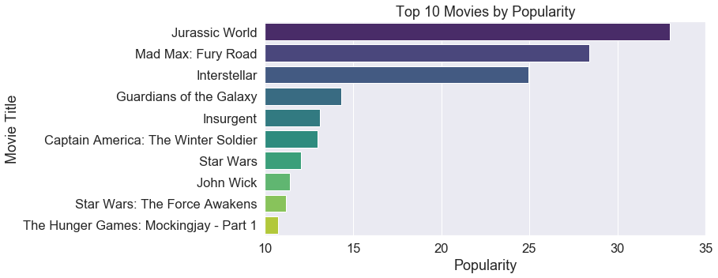

```python
#Get a list of the top 10 movies by voting average
top10 = data.nlargest(10,'popularity')

#Plot the top 10 movies by voting average
sb.set(style="darkgrid");
sb.set(font_scale=1.5);
f, ax = plt.subplots(figsize=(10, 5));
ax = sb.barplot(x='popularity', y='original_title', data=top10, palette="viridis");

ax.set(xlim=(10,35), ylabel="Movie Title", xlabel="Popularity");
plt.title('Top 10 Movies by Popularity');
```

### 6. What is the average runtime of all movies and further analysis:

```python
data['runtime'].mean()
```

```
106.04016064257029
```

The average runtime of all movies in this dataset is 106 mins approx. We want to get a deeper look and understanding of runtime of all movies so Let's plot it.

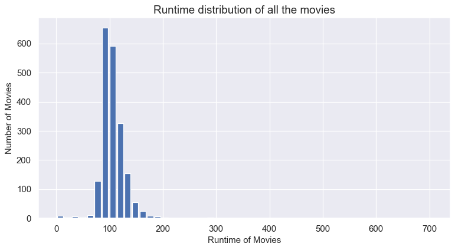

```python
#plotting a histogram of runtime of movies

#gives styles to bg plot
sb.set_style('darkgrid')

#chaging the label size, this will change the size of all plots that we plot from now!
plt.rc('xtick', labelsize = 12)
plt.rc('ytick', labelsize = 12)

#giving the figure size(width, height)
plt.figure(figsize=(10,5), dpi = 90)

#x-axis label name
plt.xlabel('Runtime of Movies', fontsize = 12)

#y-axis label name
plt.ylabel('Number of Movies', fontsize=12)

#title of the graph
plt.title('Runtime distribution of all the movies', fontsize=15)

#giving a histogram plot
plt.hist(data['runtime'], rwidth = 0.8, bins =50)
#displays the plot
plt.show()
```

### 7. Calculating top 10 by count.....

### Which directors made maximum no of movies?

```python
# Top 10 Directors by movie count:
director_count = pd.Series(data['director']).value_counts(ascending=False)

#showing top 10 values
print("Top 10 directors with max no of movies all over along with count of movies directed by them are")
director_count.head(10)
```

```
Top 10 directors with max no of movies all over along with count of movies directed by them are
```

```
John Carpenter        17
Steven Spielberg      11
Steven Soderbergh     11
Robert Zemeckis        8
Ridley Scott           8
Clint Eastwood         8
Peter Jackson          8
Paul W.S. Anderson     7
Ron Howard             7
David Fincher          7
Name: director, dtype: int64
```

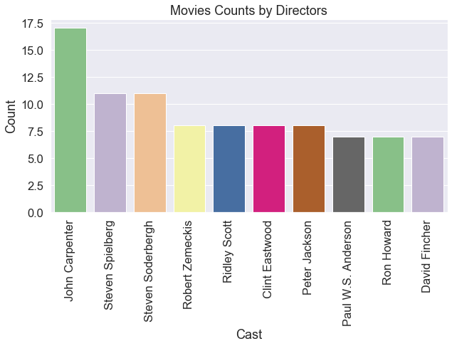

```python
director_graph= director_count.head(10)
sb.set_style("darkgrid")
sb.set(font_scale=1.5);
f, axis = plt.subplots(figsize=(10, 5));

axis = sb.barplot(x=director_graph.index, y=director_graph.values, palette="Accent");

axis.set( ylabel="Count", xlabel="Cast");
plt.title('Movies Counts by Directors');
plt.xticks(rotation=90);
```

## Conclusions

- The year with maximum no. of movie release has shown a gradual increase over the years.

-The mean value of revenue_adj is 130239074.05593592

```
-And then we compared the skewness of various trends with revenue_dj.
```

-In the list of Top 10 movies by voting average-The Godfather is at the first place.

- In the list of Top 10 movies by popularity -Jurassic World is at the first place.

-Average runtime of the movies comes out to be 106 .

-Director -John Carpenter has directed maximum no. of movies.

## Resources(Websites I referred to for the project)

1.https://www.dummies.com/education/math/statistics/how-to-identify-skew-and-symmetry-in-a-statistical-histogram/

2.https://www.shmoop.com/study-guides/pre-algebra/basic-statistics-probability/scatter-plots-correlation

3.https://matplotlib.org/api/pyplot_api.html#matplotlib.pyplot.bar